# P&S-2022: Lab assignment 2

Shevchenko Ivan, Zarichanska Yelyzaveta, Shchur Oleksandr

## Work-breakdown structure

- Task1 : Zarichanska Yelyzaveta
- Task2 : Shchur Oleksandr
- Task3 : Shevchenko Ivan

```r
id <- 26
set.seed(id)
```

## General comments and instructions

- Complete solution will give you $\bf 4$ points (out of 100 total). Submission deadline is **23:59 of 06 November 2022**
- The report must be prepared as an *R notebook*; you must submit to **cms** both the source *R notebook* **and** the generated html file
- At the beginning of the notebook, provide a work-breakdown structure estimating efforts of each team member
- For each task, include
  - problem formulation and discussion (what is a reasonable answer to discuss);
  - the corresponding $\mathbf{R}$ code with comments (usually it is just a couple of lines long);
  - the statistics obtained (like sample mean or anything else you use to complete the task) as well as histograms etc to illustrate your findings;
  - justification of your solution (e.g. refer to the corresponding theorems from probability theory);
  - conclusions (e.g. how reliable your answer is, does it agree with common sense expectations etc)
- The **team id number** referred to in tasks is the **two-digit** ordinal number of your team on the list. Include the line **set.seed(team id number)** at the beginning of your code to make your calculations reproducible. Also observe that the answers **do** depend on this number!
- Take into account that not complying with these instructions may result in point deduction regardless of whether or not your implementation is correct.

### Task 1

#### In this task, we discuss the $[7,4]$ Hamming code and investigate its reliability. That coding system can correct single errors in the transmission of $4$-bit messages and proceeds as follows:

- given a message $\mathbf{m} = (a_1 a_2 a_3 a_4)$, we first encode it to a $7$-bit *codeword* $\mathbf{c} = \mathbf{m}G = (x_1 x_2 x_3 x_4 x_5 x_6 x_7)$, where $G$ is a $4\times 7$ *generator* matrix
- the codeword $\mathbf{c}$ is transmitted, and $\mathbf{r}$ is the received message
- $\mathbf{r}$ is checked for errors by calculating the *syndrome vector* $\mathbf{z} := \mathbf{r} H$, for a $7 \times 3$ *parity-check* matrix $H$
- if a single error has occurred in $\mathbf{r}$, then the binary $\mathbf{z} = (z_1 z_2 z_3)$ identifies the wrong bit no. $z_1 + 2 z_2 + 4z_3$; thus $(0 0 0)$ shows there was no error (or more than one), while $(1 1 0 )$ means the third bit (or more than one) got corrupted
- if the error was identified, then we flip the corresponding bit in $\mathbf{r}$ to get the corrected $\mathbf{r}^* = (r_1 r_2 r_3 r_4 r_5 r_6 r_7)$;
- the decoded message is then $\mathbf{m}^*:= (r_3r_5r_6r_7)$.

#### The **generator** matrix $G$ and the **parity-check** matrix $H$ are given by

$$G :=
\begin{pmatrix}
1 & 1 & 1 & 0 & 0 & 0 & 0 \\
1 & 0 & 0 & 1 & 1 & 0 & 0 \\
0 & 1 & 0 & 1 & 0 & 1 & 0 \\
1 & 1 & 0 & 1 & 0 & 0 & 1 \\
\end{pmatrix},
\qquad
H^\top := \begin{pmatrix}
1 & 0 & 1 & 0 & 1 & 0 & 1 \\
0 & 1 & 1 & 0 & 0 & 1 & 1 \\
0 & 0 & 0 & 1 & 1 & 1 & 1
\end{pmatrix}$$

#### Assume that each bit in the transmission $\mathbf{c} \mapsto \mathbf{r}$ gets corrupted independently of the others with probability $p = \mathtt{id}/100$, where $\mathtt{id}$ is your team number. Your task is the following one.

1. Simulate the encoding-transmission-decoding process $N$ times and find the estimate $\hat p$ of the probability $p^*$ of correct transmission of a single message $\mathbf{m}$. Comment why, for large $N$, $\hat p$ is expected to be close to $p^*$.  
   #### First, we set the **id** of the team and define the probability $p$ and the generator and parity-check matrices $G$ and $H$

   ```r
   # your team id number
   id <-    26

   set.seed(id)
   p <- id/100
   # matrices G and H
   G <- matrix(c(1, 1, 1, 0, 0, 0, 0,
           1, 0, 0, 1, 1, 0, 0,
           0, 1, 0, 1, 0, 1, 0,
           1, 1, 0, 1, 0, 0, 1), nrow = 4, byrow = TRUE)
   H <- t(matrix(c(1, 0, 1, 0, 1, 0, 1,
           0, 1, 1, 0, 0, 1, 1,
           0, 0, 0, 1, 1, 1, 1), nrow = 3, byrow = TRUE))

   #cat("The product GH must be zero: \n")
   #(G%*%H) %%2
   ```

#### Now, we generate N massages and encode them to 7-bit codewords

   ```r
   N <- 1000
   message_generator <- function(N) {
     matrix(sample(c(0,1), 4*N, replace = TRUE), nrow = N)
   }
   messages <- message_generator(N)
   codewords <- (messages %*% G) %% 2
   ```

#### Here, we generate random errors with probability $p$

   ```r
   error_generator <- function(encoded_matrix) {
       output = matrix(, nrow = N, ncol = 7)
       for (i in 1:N) {
         for (j in 1:7) {
           error_probability = runif(1, min=0, max=1)
           output[i, j] = if (error_probability <= p) xor(encoded_matrix[i, j], 1)  else encoded_matrix[i, j]
         }
       }
       return (output)
   }
   received_with_errors <- error_generator(codewords)
   ```

#### Using syndrome vector z we create a matrix with the indexes of bits that were wrongly transmitted

   ```r
   syndrome_vector <- (received_with_errors%*%H) %%2

   error_identifier <- function(z_matrix) {
     wrong_bits = matrix(, nrow = N, ncol = 1)
     for (i in 1:N) {
       wrong_bits[i,1] = z_matrix[i,1] + 2*z_matrix[i,2] + 4*z_matrix[i,3]
     }
     return (wrong_bits)
   }
   wrong_bits <- error_identifier(syndrome_vector)
   ```

#### Next, we correct wrong bits and return decoded message

   ```r
   error_corrector <- function(wrong_bits) {
     corrected_message <- matrix(, nrow = N, ncol = 4)

     for (i in 1:N) {
       received_with_errors[i, wrong_bits[i]] = if (wrong_bits[i] != 0) xor(received_with_errors[i, wrong_bits[i]], 1) else received_with_errors[i, wrong_bits[i]]
       corrected_message[i, 1] = received_with_errors[i, 3]
       corrected_message[i, 2] = received_with_errors[i, 5]
       corrected_message[i, 3] = received_with_errors[i, 6]
       corrected_message[i, 4] = received_with_errors[i, 7]
     }
     return (corrected_message)
   }

   corrected_decoded_message <- error_corrector(wrong_bits)
   ```

#### Finally, we find the estimate $\hat p$ of the probability $p^*$ of correct transmission of a single message $\mathbf{m}$

   ```r
   proper_transmissions <- 0
   for (i in 1:N) {
       a = (messages[i, 1:4] == corrected_decoded_message[i, 1:4])
       false_count = sum(a == 0)
       if (false_count == 0) {
         proper_transmissions = proper_transmissions + 1
       }
   }
   proper_transmissions/N
   ```

   ```
   ## [1] 0.447
   ```

2. By estimating the standard deviation of the corresponding indicator of success by the standard error of your sample and using the CLT, predict the interval $(p^*-\varepsilon, p^* + \varepsilon)$, in which the estimate $\hat p$ falls with probability at least $0.95$. What choice of $N$ guarantees that $\varepsilon \le 0.03$?  
   We need to prove that: P{|p^ - p*|<= 0.03} >= 0.95

dev = $\sqrt[]{p(1-p}$

Zn = ($\sqrt[]{n}$(p^ - p))/dev

Then we will find P{|p^ - p*|>= e}

A = P{|p^ - p|>= e} = P{|Zn|>=$\sqrt[]{n}$*e/$\sqrt[]{p(1-p}$} = 2P{Zn<=-$\sqrt[]{n}$*e/$\sqrt[]{p(1-p}$}

Using CLT, A ~ 2F(-$\sqrt[]{n}$*e/$\sqrt[]{p(1-p}$)

To make that be at most 0.05 with e <= 0.03 we need

$\sqrt[]{n}$*e/$\sqrt[]{p(1-p}$ >= 1.96

than we have

$\sqrt[]{n}$ >= 1.96/(2 * 0.03)

[output not shown]

### Task 2.

#### In this task, we discuss a real-life process that is well modelled by a Poisson distribution. As you remember, a Poisson random variable describes occurrences of rare events, i.e., counts the number of successes in a large number of independent random experiments. One of the typical examples is the **radioactive decay** process.

#### Consider a sample of radioactive element of mass $m$, which has a big *half-life period* $T$; it is vitally important to know the probability that during a one second period, the number of nuclei decays will not exceed some critical level $k$. This probability can easily be estimated using the fact that, given the *activity* ${\lambda}$ of the element (i.e., the probability that exactly one nucleus decays in one second) and the number $N$ of atoms in the sample, the random number of decays within a second is well modelled by Poisson distribution with parameter $\mu:=N\lambda$. Next, for the sample of mass $m$, the number of atoms is $N = \frac{m}{M} N_A$, where $N_A = 6 \times 10^{23}$ is the Avogadro constant, and $M$ is the molar (atomic) mass of the element. The activity of the element, $\lambda$, is $\log(2)/T$, where $T$ is measured in seconds.

#### Assume that a medical laboratory receives $n$ samples of radioactive element ${{}^{137}}\mathtt{Cs}$ (used in radiotherapy) with half-life period $T = 30.1$ years and mass $m = \mathtt{team\, id \,number} \times 10^{-6}$ g each. Denote by $X_1,X_2,\dots,X_n$ the **i.i.d. r.v.**’s counting the number of decays in sample $i$ in one second.

1. Specify the parameter of the Poisson distribution of $X_i$ (you’ll need the atomic mass of *Cesium-137*)
2. Show that the distribution of the sample means of $X_1,\dots,X_n$ gets very close to a normal one as $n$ becomes large and identify that normal distribution. To this end,
   - simulate the realization $x_1,x_2,\dots,x_n$ of the $X_i$ and calculate the sample mean $s=\overline{\mathbf{x}}$;
   - repeat this $K$ times to get the sample $\mathbf{s}=(s_1,\dots,s_K)$ of means and form the empirical cumulative distribution function $\hat F_{\mathbf{s}}$ of $\mathbf{s}$;
   - identify $\mu$ and $\sigma^2$ such that the $F$ of $\mathscr{N}(\mu,\sigma^2)$ is close to the $\hat F_{\mathbf{s}}$ and plot both **c.d.f.**’s on one graph to visualize their proximity (use the proper scales!);
   - calculate the maximal difference between the two ’s;
   - consider cases $n = 5$, $n = 10$, $n=50$ and comment on the results.
3. Calculate the largest possible value of $n$, for which the total number of decays in one second is less than $8 \times 10^8$ with probability at least $0.95$. To this end,
   - obtain the theoretical bound on $n$ using Markov inequality, Chernoff bound and Central Limit Theorem, and compare the results;
   - simulate the realization $x_1,x_2,\dots,x_n$ of the $X_i$ and calculate the sum $s=x_1 + \cdots +x_n$;
   - repeat this $K$ times to get the sample $\mathbf{s}=(s_1,\dots,s_K)$ of sums;
   - calculate the number of elements of the sample which are less than critical value ($8 \times 10^8$) and calculate the empirical probability; comment whether it is close to the desired level $0.95$

```r
setup <- function(id){
  N_avogadro <- 6.022 * 1e23
  Time <- 30.1 * 365 * 24 * 60 * 60 # half-life time in seconds
  m <- id * 1e-6 # mass of each sample in grams
  M <- 136.907089 # Atomic mass of Caesium-137.

  lambda <- log(2) / Time # The activity of the single element
  N <- (m * N_avogadro) / M # The amount of atoms in the sample
  mu <- N * lambda # Poisson distribution parameter
  return(mu)
}

samples_generation <- function(n, k, mu){
  set.seed(id)
  n <- n # samples quantity
  K <- k # Number of trials
  sample_means <- colMeans(matrix(rpois(n * K, lambda = mu), nrow = n)) # Generating samples and calculating their means.
  return(sample_means)
}

mu = setup(id)

n = 100
sample_means = samples_generation(n, 1e3, mu)
```

#### Next, calculate the parameters of the standard normal approximation

Let’s denote as $S_n$ the sum of i.i.d.r.v.: $S_n$ = $X_1 + X_2 + ... + X_n$.

Then:

$E[S_n] = nE[X_i] = n \mu \\ Var[S_n] = n \sigma ^ 2$

$M_n = S_n/n \\ E[M_n] = E[S_n/n] = \mu \\ Var[M_n] = \sigma ^2 / n → 0$ Let’s consider the standardized sums $Z_n=\frac {\sqrt{n}}{σ}(M_n−μ)= \frac{S_n−μn}{σ \sqrt{n}}.$

By the CLT, $Z_n$ converge in law to $Z∼N(0,1)$. $M_n = Z_n \frac {σ}{\sqrt{n}} + \mu$, therefore $M_n ∼ N(\mu, \frac {σ^2}{n})$.

As $X_i$ has the Poisson distribution, $Var[X_i] = \lambda = \sigma^2$. Hence $\sigma = \sqrt{\lambda}$

$\sigma_1 = \frac {σ}{\sqrt{n}} = \sqrt{\frac {\lambda}{n}}$

$\mu_1 = \mu$

$M_n ∼ N(\mu_1, \sigma_1^2)$

```r
sigma_1 <- sqrt(mu / n) # lambda is denoted as mu in this task
mu_1 <- mu
#mu_1
#sigma_1
```

#### We can now plot ecdf and cdf

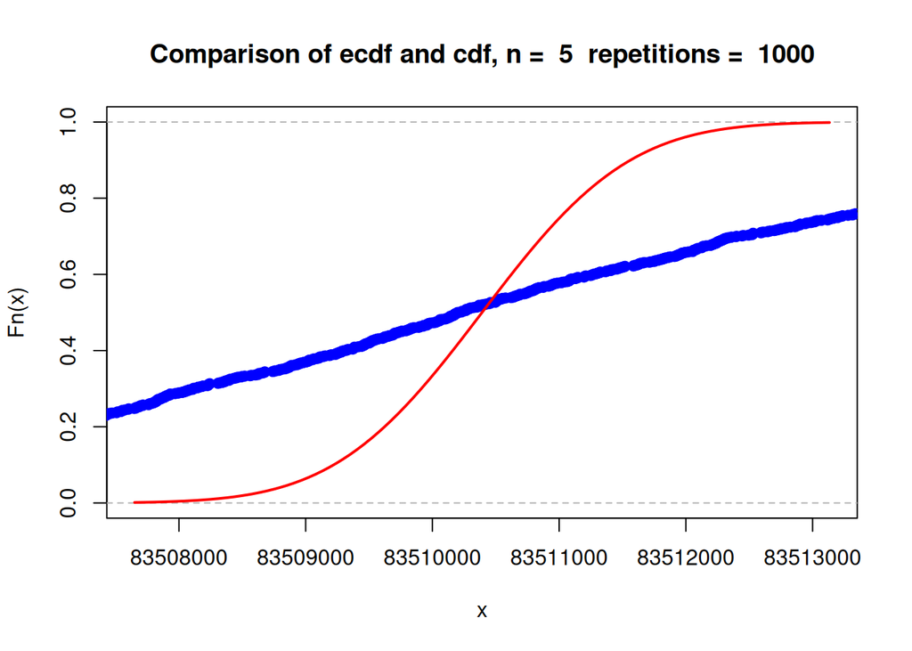

```
## [1] "Max difference is:  0.313646309693677"
```

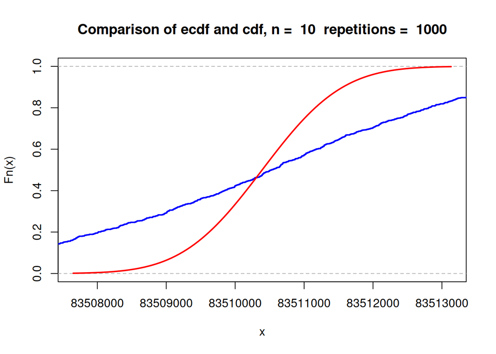

```
## [1] "Max difference is:  0.258741593445779"
```

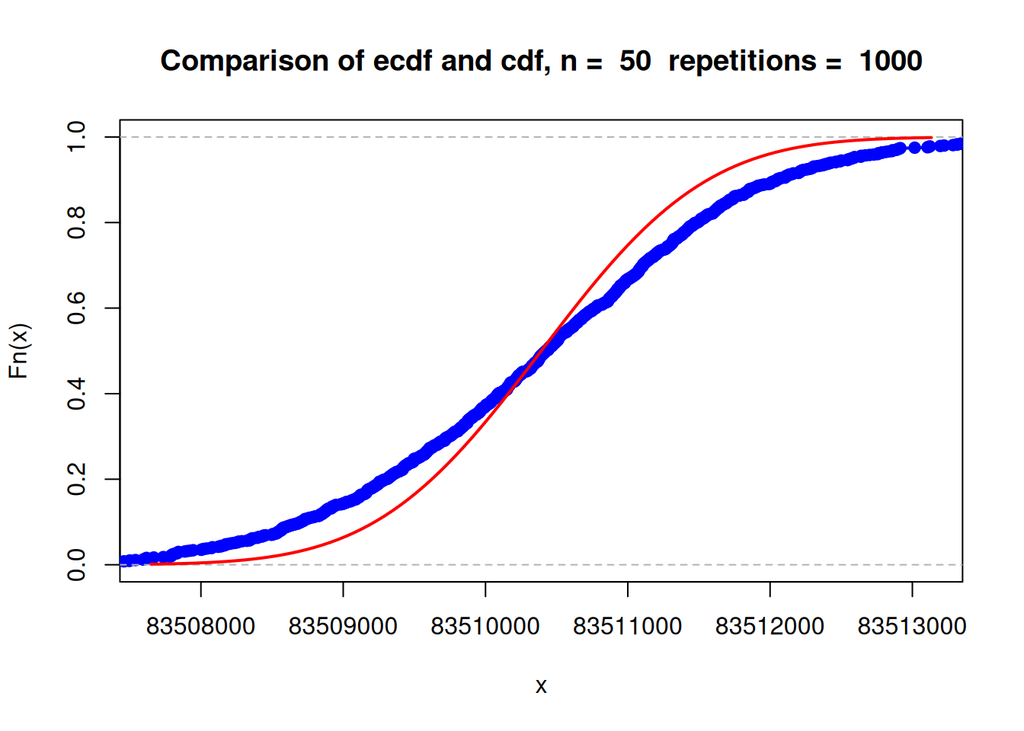

```
## [1] "Max difference is:  0.0933726884185432"
```

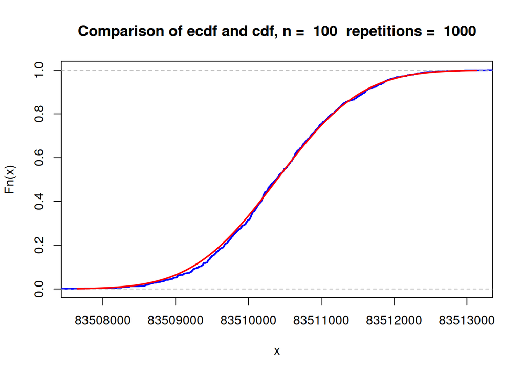

```
## [1] "Max difference is:  0.0263599360242188"
```

```r
plot_cdf <- function(sample_means, n){
xlims <- c(mu_1 - 3 * sigma_1, mu_1 + 3 * sigma_1)
x <- seq(mu_1 - 3 * sigma_1, mu_1 + 3 * sigma_1, by = .001)
Fs <- ecdf(sample_means)
plot(Fs,
     xlim = xlims,
     ylim = c(0, 1),
     col = "blue",
     lwd = 2,
     main = paste("Comparison of ecdf and cdf, n = ", n, " repetitions = ", length(sample_means)))
curve(pnorm(x, mean = mu_1, sd = sigma_1), col = "red", lwd = 2, add = TRUE)

max_diff = max(abs(ecdf(sample_means)(x)-pnorm(x, mean = mu_1, sd = sigma_1)))
print(paste("Max difference is: ", max_diff))
}
for (x in c(5,10,50, 100)) {
  sigma_1 <- sqrt(mu / n) # lambda is denoted as mu in this task
  mu_1 <- mu
  sample_means = samples_generation(x, 1e3, mu)
  plot_cdf(sample_means, x)
}
```